# Forest Fires in Brazil

Carlos Habekost

18/11/2019

## Introduction

This document is aiming to analysis the forest fires that occurred in Brazil from 1998 to 2017. Forest Fires are a critical problem for the Tropical Forest in Brazil. I obtained this data from [kaggle.com](https://www.kaggle.com/gustavomodelli/forest-fires-in-brazil), who organized the data initially derived from the official website of the [Brazilian government](http://dados.gov.br/dataset/sistema-nacional-de-informacoes-florestais-snif).

With this analysis, we can identify fires occurred in Brazilian states, considering: Year, month e number of Fires happened.

## Analisys Performed

- **year:** when Forest Fires happened
- **state:** Brazilian State
- **month:** Month when Forest Fires happened
- **number:** Number of Forest Fires reported
- **date:** Date when Forest Fires where reported

I had a pre-processing in the data set, aiming to perform correctly in this markdown:

- *Months*: Originally was in Portuguese, I standardization in English.
- *Standardization of State name accents*: Originally in this data set, the name of some States had an accent; I normalization without accent to avoid issues during the execution of this markdown.

```r
reportFires <- read.csv(file="amazon.csv")

#print(reportFires)
```

With the data ready, I first summarize some information about the dataset:

```r
summary(reportFires)
```

```
##       year              state           month          number
##  Min.   :1998   Rio        : 717   January : 541   Min.   :    0.0
##  1st Qu.:2002   Mato Grosso: 478   April   : 540   1st Qu.:    9.0
##  Median :2007   Paraiba    : 478   August  : 540   Median :   54.0
##  Mean   :2007   Alagoas    : 240   February: 540   Mean   :  522.7
##  3rd Qu.:2012   Acre       : 239   July    : 540   3rd Qu.:  269.0
##  Max.   :2017   Amapa      : 239   June    : 540   Max.   :25963.0
##                 (Other)    :4063   (Other) :3213
##          date
##  1998-01-01: 324
##  1999-01-01: 324
##  2000-01-01: 324
##  2001-01-01: 324
##  2002-01-01: 324
##  2003-01-01: 324
##  (Other)   :4510
```

Second, using ggplot, I plot a heatmap aiming to identify the most reported state with fires. It is evident that the state of Mato Grosso is most affected by fires (totaling 250000+ fires reported):

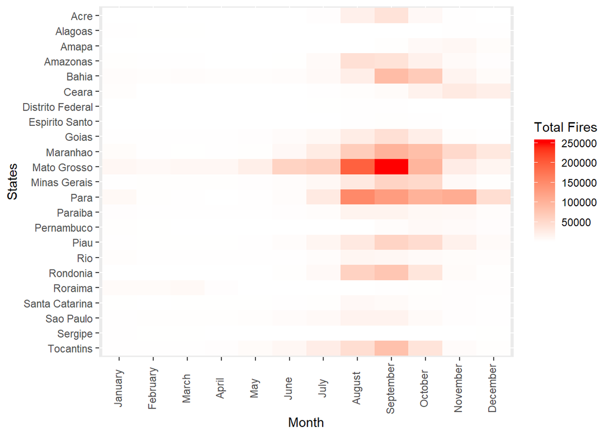

```r
library(dplyr)

analyzedData2 <- reportFires %>% select(-date) %>%
  group_by(state, month) %>%
  summarise(totalFires = sum(number))


var <- analyzedData2 %>%
  mutate(month = factor(month, levels = c("January", "February","March", "April", "May", "June", "July", "August", "September", "October", "November", "December")))
  #%>%

ggplot(var, aes(x=month,y=reorder(state,desc(state)),fill=totalFires)) +
  geom_tile() +
  scale_fill_gradient(low = "white", high = "red") +
  theme(axis.text.x = element_text(angle = 90, vjust=0.25)) +
  xlab( "Month" ) +
  ylab( "States" ) +
  labs(fill="Total Fires")
```

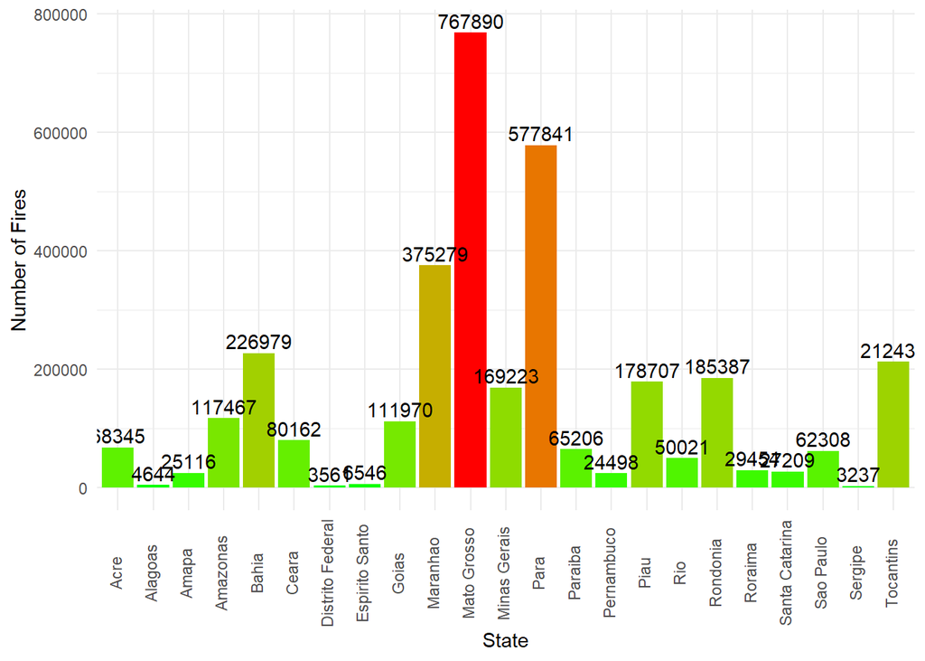

```r
# Library
library(ggplot2)

var %>% group_by(state) %>% summarise(totalFires = sum(totalFires)) %>%
ggplot(aes(x=state,y = totalFires, fill=totalFires)) +
  geom_col() +
  xlab( "State" ) +
  ylab( "Number of Fires" )+
  scale_fill_gradient(low = "green", high = "red") +
  geom_text(aes(label=totalFires), vjust=-0.3) +
  theme_minimal() +
  theme(axis.text.x = element_text(angle = 90, vjust=0.25), legend.position = "none")
```

In the fourth analysis, I considered the month with more cases of fire, considering all fires reported. As a result, I identified that September has the most number of fire reports (totalizing 1,015,925), after August (740,841 reports) and October (629,665 reports).

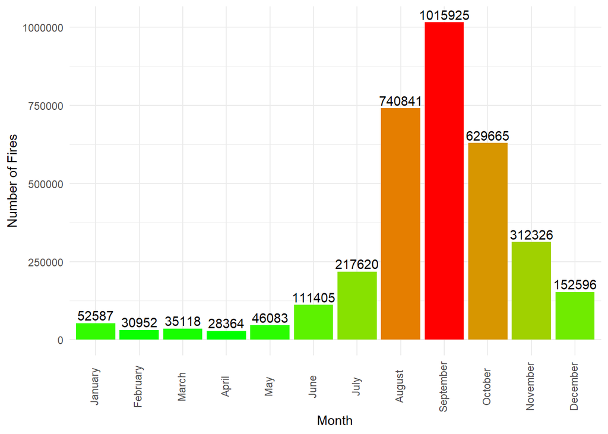

```r
# Library
library(ggplot2)

var %>% group_by(month) %>% summarise(totalFires = sum(totalFires)) %>%
ggplot(aes(x=month,y = totalFires, fill=totalFires)) +
  geom_col() +
  xlab( "Month" ) +
  ylab( "Number of Fires" )+
  scale_fill_gradient(low = "green", high = "red") +
  geom_text(aes(label=totalFires), vjust=-0.3) +
  theme_minimal() +
  theme(axis.text.x = element_text(angle = 90, vjust=0.25), legend.position = "none")
```

Finally, I tried to perform other analyzes using ggplot. However, I did not obtain an expressive result to include in this work.

As an example, I present an analysis considering the state of the Mato Grosso, using a histogram graph. However, the obtained graph has a few analysis values. Also, I tried to plot this graph, considering the data for all states. However, the results obtained were similar to the heatmap graph.

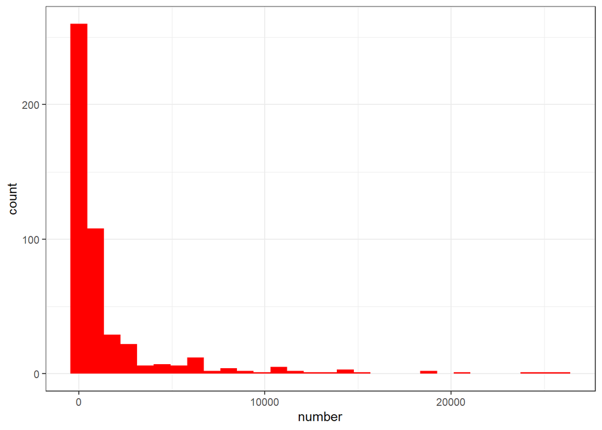

```r
# Library
library(ggplot2)

reportFires %>% filter(state =="Mato Grosso") %>%
  ggplot(aes(x=number)) +
  geom_histogram(fill = 'red', bins=30) +
  theme_bw()
```